# anemia_detection

```python
import pandas as pd
import seaborn as sns
import numpy as np
import matplotlib.pyplot as plt
plt.style.use('fivethirtyeight')
import warnings
warnings.filterwarnings('ignore')
%matplotlib inline
from sklearn import preprocessing
import scipy.stats as ss
from sklearn.model_selection import train_test_split
from sklearn import metrics
from sklearn.metrics import confusion_matrix
from sklearn.metrics import RocCurveDisplay
%matplotlib inline
sns.set()
from sklearn.metrics import classification_report

from sklearn.metrics import roc_curve, roc_auc_score
```

```python
input = "anemia dataset.csv"
```

```python
df=pd.read_csv(input)
df.head()
```

|  | gender(0_male and 1_female) | Hemoglobin | mch | mchc | mcv | result |
| --- | --- | --- | --- | --- | --- | --- |
| 0 | 1 | 14.9 | 22.7 | 29.1 | 83.7 | 0 |
| 1 | 0 | 15.9 | 25.4 | 28.3 | 72.0 | 0 |
| 2 | 0 | 9.0 | 21.5 | 29.6 | 71.2 | 1 |
| 3 | 0 | 14.9 | 16.0 | 31.4 | 87.5 | 0 |
| 4 | 1 | 14.7 | 22.0 | 28.2 | 99.5 | 0 |

```python
df.describe()
```

|  | gender(0_male and 1_female) | Hemoglobin | mch | mchc | mcv | result |
| --- | --- | --- | --- | --- | --- | --- |
| count | 1421.000000 | 1421.000000 | 1421.000000 | 1421.000000 | 1421.000000 | 1421.000000 |
| mean | 0.520760 | 13.412738 | 22.905630 | 30.251232 | 85.523786 | 0.436312 |
| std | 0.499745 | 1.974546 | 3.969375 | 1.400898 | 9.636701 | 0.496102 |
| min | 0.000000 | 6.600000 | 16.000000 | 27.800000 | 69.400000 | 0.000000 |
| 25% | 0.000000 | 11.700000 | 19.400000 | 29.000000 | 77.300000 | 0.000000 |
| 50% | 1.000000 | 13.200000 | 22.700000 | 30.400000 | 85.300000 | 0.000000 |
| 75% | 1.000000 | 15.000000 | 26.200000 | 31.400000 | 94.200000 | 1.000000 |
| max | 1.000000 | 16.900000 | 30.000000 | 32.500000 | 101.600000 | 1.000000 |

```python
df['result'].value_counts()
```

```
result
0    801
1    620
Name: count, dtype: int64
```

```python
male= df[df['gender(0_male and 1_female)']==0]
female= df[df['gender(0_male and 1_female)']==1]
```

```python
male.describe()
```

|  | gender(0_male and 1_female) | Hemoglobin | mch | mchc | mcv | result |
| --- | --- | --- | --- | --- | --- | --- |
| count | 681.0 | 681.000000 | 681.000000 | 681.000000 | 681.000000 | 681.000000 |
| mean | 0.0 | 13.390162 | 22.901322 | 30.229956 | 85.929956 | 0.305433 |
| std | 0.0 | 2.047166 | 4.160460 | 1.377748 | 9.695412 | 0.460929 |
| min | 0.0 | 6.600000 | 16.000000 | 27.800000 | 69.500000 | 0.000000 |
| 25% | 0.0 | 11.600000 | 19.300000 | 29.100000 | 77.500000 | 0.000000 |
| 50% | 0.0 | 13.400000 | 22.800000 | 30.200000 | 85.300000 | 0.000000 |
| 75% | 0.0 | 15.000000 | 26.400000 | 31.400000 | 94.800000 | 1.000000 |
| max | 0.0 | 16.900000 | 29.800000 | 32.500000 | 101.600000 | 1.000000 |

```python
df.columns
```

```
Index(['gender(0_male and 1_female)', 'Hemoglobin', 'mch', 'mchc', 'mcv',
       'result'],
      dtype='object')
```

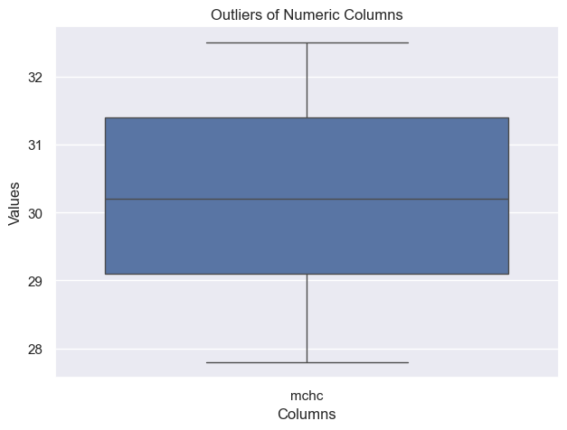

```python
sns.boxplot(data=male[['mchc']])

# Set plot title and axis labels
plt.title('Outliers of Numeric Columns')
plt.xlabel('Columns')
plt.ylabel('Values')

# Show the plot
plt.show()
```

```python
df.info()#data type of each column
```

```
<class 'pandas.core.frame.DataFrame'>
RangeIndex: 1421 entries, 0 to 1420
Data columns (total 6 columns):
 #   Column                       Non-Null Count  Dtype
---  ------                       --------------  -----
 0   gender(0_male and 1_female)  1421 non-null   int64
 1   Hemoglobin                   1421 non-null   float64
 2   mch                          1421 non-null   float64
 3   mchc                         1421 non-null   float64
 4   mcv                          1421 non-null   float64
 5   result                       1421 non-null   int64
dtypes: float64(4), int64(2)
memory usage: 66.7 KB
```

```python
#here no null value after counting
df.isnull().sum()
```

```
gender(0_male and 1_female)    0
Hemoglobin                     0
mch                            0
mchc                           0
mcv                            0
result                         0
dtype: int64
```

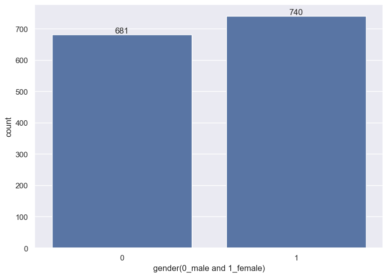

```python
#Univariate analysis
plt.figure(figsize=(8,6))
ax = sns.countplot(x = df['gender(0_male and 1_female)'])
ax.bar_label(ax.containers[0])
plt.show()
```

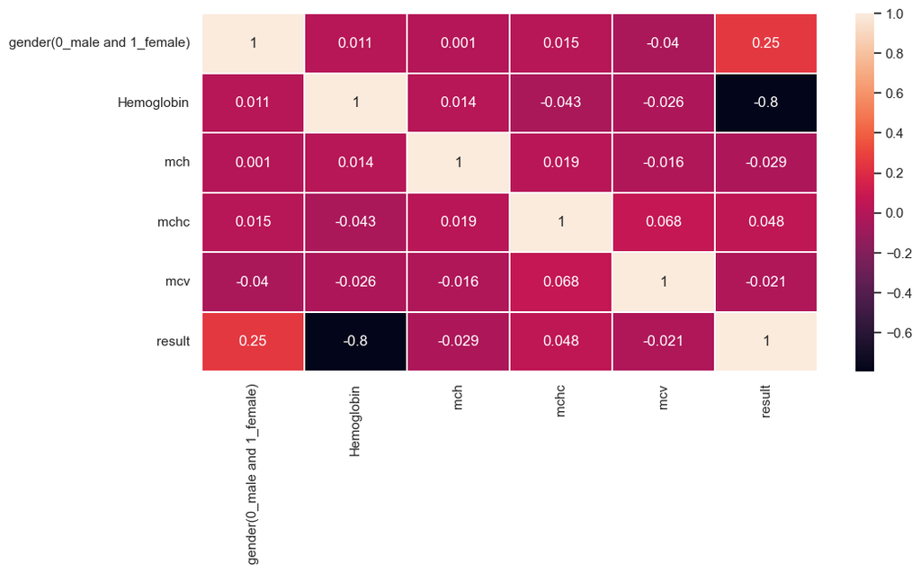

```python
#Heat map
f,ax = plt.subplots(figsize = (10, 5))
sns.heatmap(df.corr(), annot = True, linewidths = 0.2)
plt.show()
```

```python
#now we implement ml 5 models
train,test=train_test_split(df,test_size=0.2,random_state=0,stratify=df['result'])
train_X=train[train.columns[:-1]]
train_Y=train[train.columns[-1:]]
test_X=test[test.columns[:-1]]
test_Y=test[test.columns[-1:]]

X=df[df.columns[:-1]]
Y=df['result']
len(train_X), len(train_Y), len(test_X), len(test_Y)
```

```
(1136, 1136, 285, 285)
```

```python
test_Y
```

|  | result |
| --- | --- |
| 429 | 0 |
| 755 | 0 |
| 1078 | 0 |
| 207 | 1 |
| 845 | 1 |
| ... | ... |
| 458 | 0 |
| 77 | 0 |
| 1122 | 1 |
| 483 | 1 |
| 1052 | 0 |

285 rows × 1 columns

```python
from sklearn.linear_model import LogisticRegression
from sklearn.tree import DecisionTreeClassifier
from sklearn.ensemble import RandomForestClassifier
from sklearn.naive_bayes import GaussianNB
from sklearn.ensemble import ExtraTreesClassifier
from sklearn.neighbors import KNeighborsClassifier
from xgboost.sklearn import XGBClassifier
from lightgbm import LGBMClassifier
```

```python
#Naive bayes
from sklearn.naive_bayes import GaussianNB
model_nb=GaussianNB()
model_nb.fit(train_X,train_Y)
```

```
GaussianNB()
```

```python
import pickle

# Save the model to a file
filename = 'GaussianNB.pkl'
with open(filename, 'wb') as file:
    pickle.dump(model_nb, file)

print(f"Model saved to {filename}")
```

```
Model saved to GaussianNB.pkl
```

```python
pred=model_nb.predict(test_X)
pred
```

```
array([0, 0, 0, 1, 1, 1, 0, 0, 0, 1, 1, 0, 1, 1, 1, 1, 1, 0, 1, 0, 1, 0,
       1, 1, 0, 0, 1, 1, 0, 0, 0, 0, 1, 0, 1, 0, 0, 0, 0, 0, 1, 0, 0, 1,
       0, 1, 0, 0, 1, 0, 0, 0, 0, 0, 0, 0, 0, 1, 1, 1, 1, 1, 0, 1, 0, 0,
       0, 0, 1, 0, 1, 1, 0, 1, 0, 0, 1, 1, 1, 1, 0, 0, 0, 1, 1, 0, 0, 1,
       1, 0, 0, 0, 1, 1, 1, 0, 1, 0, 1, 1, 0, 0, 1, 1, 1, 0, 0, 0, 1, 0,
       1, 0, 1, 0, 1, 1, 0, 1, 0, 0, 1, 1, 1, 0, 1, 0, 0, 1, 0, 1, 0, 1,
       1, 1, 1, 0, 1, 0, 0, 1, 0, 1, 1, 1, 0, 1, 0, 1, 0, 1, 1, 0, 1, 0,
       0, 0, 0, 0, 0, 1, 0, 0, 0, 1, 1, 1, 0, 1, 1, 1, 1, 1, 1, 1, 0, 1,
       0, 1, 0, 0, 0, 0, 1, 1, 1, 1, 1, 1, 0, 1, 0, 0, 1, 0, 0, 0, 1, 1,
       0, 0, 1, 0, 1, 0, 1, 0, 0, 0, 0, 0, 0, 1, 0, 1, 0, 0, 0, 0, 0, 0,
       0, 1, 1, 0, 0, 1, 0, 0, 0, 1, 0, 0, 0, 1, 1, 0, 0, 0, 0, 1, 1, 1,
       1, 1, 1, 0, 1, 0, 1, 0, 0, 1, 1, 1, 0, 0, 0, 0, 0, 0, 0, 0, 0, 0,
       0, 1, 1, 0, 0, 1, 0, 1, 1, 1, 0, 1, 1, 1, 0, 1, 0, 0, 1, 1, 0],
      dtype=int64)
```

```python
model_nb.score(test_X,test_Y)
```

```
0.9578947368421052
```

```python
print(classification_report(test_Y, pred))
```

```
              precision    recall  f1-score   support

           0       0.99      0.94      0.96       161
           1       0.92      0.98      0.95       124

    accuracy                           0.96       285
   macro avg       0.96      0.96      0.96       285
weighted avg       0.96      0.96      0.96       285
```

```python
from sklearn.metrics import confusion_matrix
from sklearn.metrics import confusion_matrix, ConfusionMatrixDisplay

cm = confusion_matrix(test_Y,pred)
cm
```

```
array([[151,  10],
       [  2, 122]], dtype=int64)
```

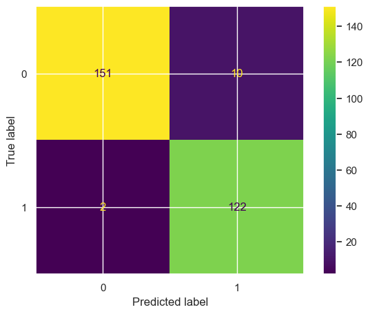

```python
cm_display = ConfusionMatrixDisplay(cm)
cm_display.plot()
plt.show()
```

```python
import matplotlib.pyplot as plt

def plot_roc_curve(test_Y,pred):
    """
    plots the roc curve based of the probabilities
    """

    fpr, tpr, thresholds = roc_curve(test_Y,pred)
    plt.plot(fpr, tpr)
    plt.xlabel('False Positive Rate')
    plt.ylabel('True Positive Rate')
```

```
model naive bayes AUC score: 0.9608795832498498
```

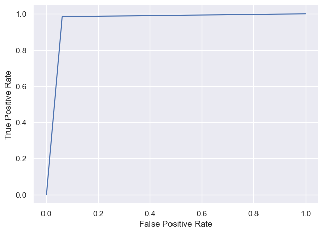

```python
plot_roc_curve(test_Y,pred)
print(f'model naive bayes AUC score: {roc_auc_score(test_Y,pred)}')
```

```python
#KNN
knn = KNeighborsClassifier(n_neighbors=15)
clf = knn.fit(train_X,train_Y)
y_pred = clf.predict(test_X)
acc_knb_model=roc_auc_score(test_Y, y_pred)*100
acc_knb_model
```

```
90.09967942296132
```

```python
# Save the model to a file
filename = 'knn.pkl'
with open(filename, 'wb') as file:
    pickle.dump(clf, file)

print(f"Model saved to {filename}")
```

```
Model saved to knn.pkl
```

```python
print(classification_report(test_Y, y_pred))
```

```
              precision    recall  f1-score   support

           0       0.92      0.91      0.91       161
           1       0.88      0.90      0.89       124

    accuracy                           0.90       285
   macro avg       0.90      0.90      0.90       285
weighted avg       0.90      0.90      0.90       285
```

```python
from sklearn.metrics import confusion_matrix

cm = confusion_matrix(test_Y,y_pred)
cm
```

```
array([[146,  15],
       [ 13, 111]], dtype=int64)
```

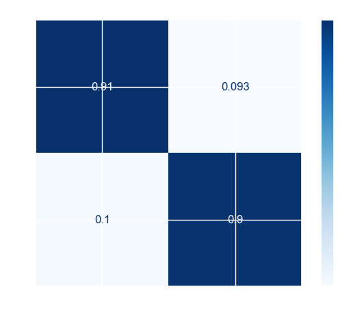

```python
import matplotlib.pyplot as plt
from sklearn.metrics import confusion_matrix, ConfusionMatrixDisplay

import matplotlib.pyplot as plt
from sklearn.metrics import confusion_matrix, ConfusionMatrixDisplay

color = 'white'
y_pred = knn.predict(test_X)
cm = confusion_matrix(test_Y, y_pred, normalize='true')
disp = ConfusionMatrixDisplay(confusion_matrix=cm, display_labels=knn.classes_)
disp.plot(cmap=plt.cm.Blues)
plt.title('Confusion Matrix', color=color)
plt.xlabel('Predicted Label', color=color)
plt.ylabel('True Label', color=color)
plt.gcf().axes[0].tick_params(colors=color)
plt.gcf().axes[1].tick_params(colors=color)
plt.show()
```

```python
import matplotlib.pyplot as plt

def plot_roc_curve(test_Y,pred):
    """
    plots the roc curve based of the probabilities
    """

    fpr, tpr, thresholds = roc_curve(test_Y,y_pred)
    plt.plot(fpr, tpr)
    plt.xlabel('False Positive Rate')
    plt.ylabel('True Positive Rate')
```

```
model knn AUC score: 0.9009967942296132
```

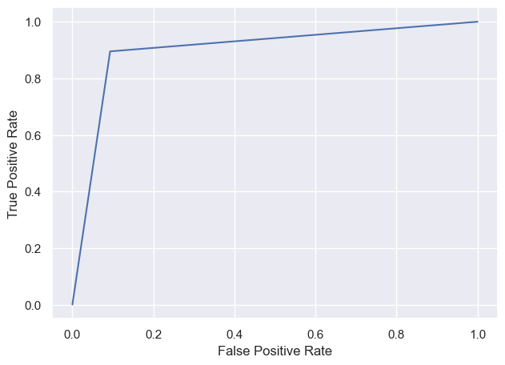

```python
plot_roc_curve(test_Y,pred)
print(f'model knn AUC score: {roc_auc_score(test_Y,y_pred)}')
```

```python
#Random forest
RFC = RandomForestClassifier(n_estimators=50, random_state=0,
                         oob_score = True,
                         max_depth = 16)
RFC.fit(train_X,train_Y)
```

```
RandomForestClassifier(max_depth=16, n_estimators=50, oob_score=True,
                       random_state=0)
```

```python
# Save the model to a file
filename = 'RandomForest.pkl'
with open(filename, 'wb') as file:
    pickle.dump(RFC, file)

print(f"Model saved to {filename}")
```

```
Model saved to RandomForest.pkl
```

```python
y_pred = RFC.predict(test_X)
```

```python
print(classification_report(test_Y, y_pred))
```

```
              precision    recall  f1-score   support

           0       1.00      1.00      1.00       161
           1       1.00      1.00      1.00       124

    accuracy                           1.00       285
   macro avg       1.00      1.00      1.00       285
weighted avg       1.00      1.00      1.00       285
```

```python
from sklearn.metrics import confusion_matrix

cm = confusion_matrix(test_Y,y_pred)
cm
```

```
array([[161,   0],
       [  0, 124]], dtype=int64)
```

```python
cm_display = ConfusionMatrixDisplay(cm)
cm_display.plot()
plt.show()
```

[output not shown]

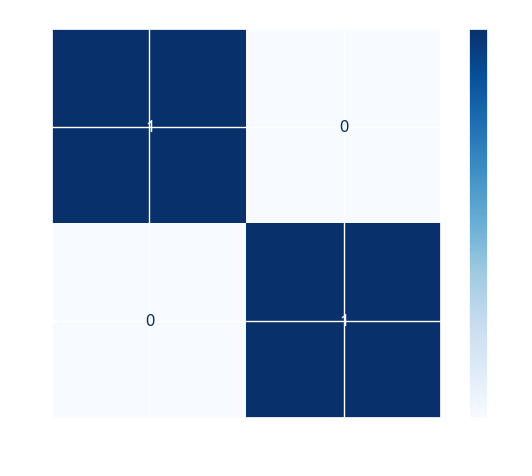

```python
import matplotlib.pyplot as plt
from sklearn.metrics import confusion_matrix, ConfusionMatrixDisplay

import matplotlib.pyplot as plt
from sklearn.metrics import confusion_matrix, ConfusionMatrixDisplay

color = 'white'
y_pred = RFC.predict(test_X)
cm = confusion_matrix(test_Y, y_pred, normalize='true')
disp = ConfusionMatrixDisplay(confusion_matrix=cm, display_labels=knn.classes_)
disp.plot(cmap=plt.cm.Blues)
plt.title('Confusion Matrix', color=color)
plt.xlabel('Predicted Label', color=color)
plt.ylabel('True Label', color=color)
plt.gcf().axes[0].tick_params(colors=color)
plt.gcf().axes[1].tick_params(colors=color)
plt.show()
```

```python
plot_roc_curve(test_Y,y_pred)
print(f'model Random forest AUC score: {roc_auc_score(test_Y,y_pred)}')
```

[output not shown]

```
model Random forest AUC score: 1.0
```

```python
#XGB
XGB_model=XGBClassifier()
XGB_model.fit(train_X,train_Y)
XGB_pred=XGB_model.predict(test_X)
acc_xgb=round(XGB_model.score(train_X,train_Y)*100,10)
acc_xgb
```

```
100.0
```

```python
# Save the model to a file
filename = 'XGBoost.pkl'
with open(filename, 'wb') as file:
    pickle.dump(XGB_model, file)

print(f"Model saved to {filename}")
```

```
Model saved to XGBoost.pkl
```

```python
y_pred4 =XGB_model.predict(test_X)
```

```python
print(classification_report(test_Y, y_pred4))
```

```
              precision    recall  f1-score   support

           0       1.00      1.00      1.00       161
           1       1.00      1.00      1.00       124

    accuracy                           1.00       285
   macro avg       1.00      1.00      1.00       285
weighted avg       1.00      1.00      1.00       285
```

```python
from sklearn.metrics import confusion_matrix

cm = confusion_matrix(test_Y, y_pred4)
cm
```

```
array([[161,   0],
       [  0, 124]], dtype=int64)
```

```python
cm_display = ConfusionMatrixDisplay(cm)
cm_display.plot()
plt.show()
```

[output not shown]

```python
plot_roc_curve(test_Y,y_pred4)
print(f'model XGB AUC score: {roc_auc_score(test_Y,y_pred4)}')
```

[output not shown]

```
model XGB AUC score: 1.0
```

```python
#Decision tree
from sklearn import tree
from sklearn.metrics import accuracy_score
import tensorflow as tf
```

```python
DecisionTree_model = tree.DecisionTreeClassifier()
DecisionTree_model.fit(train_X,train_Y)

pred = DecisionTree_model.predict(test_X)
accuracy = accuracy_score(pred, test_Y)
print(DecisionTree_model)
print(accuracy)
print(classification_report(pred, test_Y, labels=None))
```

```
DecisionTreeClassifier()
1.0
              precision    recall  f1-score   support

           0       1.00      1.00      1.00       161
           1       1.00      1.00      1.00       124

    accuracy                           1.00       285
   macro avg       1.00      1.00      1.00       285
weighted avg       1.00      1.00      1.00       285
```

```python
np.unique(pred)
```

```
array([0, 1], dtype=int64)
```

```python
# Save the model to a file
filename = 'decisiontree.pkl'
with open(filename, 'wb') as file:
    pickle.dump(DecisionTree_model, file)

print(f"Model saved to {filename}")
```

```
Model saved to decisiontree.pkl
```

```python
from sklearn.metrics import confusion_matrix

cm = confusion_matrix(pred, test_Y)
cm
```

```
array([[161,   0],
       [  0, 124]], dtype=int64)
```

```python
cm_display = ConfusionMatrixDisplay(cm)
cm_display.plot()
plt.show()
```

[output not shown]

```python
plot_roc_curve(test_Y,pred)
print(f'model Decision tree AUC score: {roc_auc_score(test_Y,pred)}')
```

[output not shown]

```
model Decision tree AUC score: 1.0
```

```python
#deep learning
#CNN
import tensorflow as tf
from tensorflow import keras
from tensorflow.keras import layers
from keras.layers import Dense, Activation,Dropout, BatchNormalization
from keras import Sequential
from keras.models import load_model
from tensorflow.keras.optimizers import Adam
```

```python
from sklearn.model_selection import train_test_split
train_X,test_X,train_Y,test_Y=train_test_split(X,Y,test_size=0.2,random_state=0)
```

```python
from sklearn.preprocessing import StandardScaler

sclr = StandardScaler()
x_train = sclr.fit_transform(train_X)
x_test = sclr.transform(test_X)
```

```python
cnn_model_old = Sequential([
    Dense(128,activation = 'relu',kernel_regularizer=tf.keras.regularizers.l2(0.1)),
    Dense(40,activation = 'relu',kernel_regularizer= tf.keras.regularizers.l2(0.1)),
    Dense(1,activation= 'linear')
])
```

```python
l2_lambda = 0.01

cnn_model = Sequential([
    Dense(256, activation='relu', kernel_regularizer=tf.keras.regularizers.l2(l2_lambda)),
    BatchNormalization(),  # Normalize the activations of the previous layer at each batch
    Dropout(0.3),  # Dropout for regularization
    Dense(128, activation='relu', kernel_regularizer=tf.keras.regularizers.l2(l2_lambda)),
    BatchNormalization(),
    Dropout(0.3),
    Dense(64, activation='relu', kernel_regularizer=tf.keras.regularizers.l2(l2_lambda)),
    BatchNormalization(),
    Dropout(0.3),
    Dense(32, activation='relu', kernel_regularizer=tf.keras.regularizers.l2(l2_lambda)),
    BatchNormalization(),
    Dropout(0.3),
    # Dense(16, activation='relu', kernel_regularizer=tf.keras.regularizers.l2(l2_lambda)),
    # BatchNormalization(),
    # Dropout(0.3),
    # Dense(8, activation='relu', kernel_regularizer=tf.keras.regularizers.l2(l2_lambda)),
    # BatchNormalization(),
    # Dropout(0.3),
    Dense(1, activation='sigmoid')  # Sigmoid activation for binary classification
])
```

```python
cnn_model_old.compile(loss = tf.keras.losses.BinaryCrossentropy(from_logits=True),
              optimizer=  tf.keras.optimizers.Adam(learning_rate = 0.01),
               metrics = ["accuracy"])
cnn_model.compile(optimizer=Adam(learning_rate=0.0001), loss='binary_crossentropy', metrics=['accuracy'])
```

```python
from tensorflow.keras.callbacks import EarlyStopping, TensorBoard

# checkpoint_cnn = ModelCheckpoint('cnn_best.h5', monitor='val_loss', verbose=1, save_best_only=True, mode='min')
early_stopping = EarlyStopping(monitor='val_loss', patience=10, verbose=1, mode='min')
# reduce_lr = ReduceLROnPlateau(monitor='val_loss', factor=0.1, patience=5, min_lr=1e-6, verbose=1)
```

```python
result = cnn_model.fit(x=train_X,
                   y=train_Y,
                   batch_size=50,
                   epochs=200,
                   verbose=1,
                   validation_split=0.15,
                   callbacks=[early_stopping])
result.name='customCNN'
```

```python
result_old = cnn_model_old.fit(x=train_X,
                   y=train_Y,
                   batch_size=50,
                   epochs=200,
                   verbose=1,
                   validation_split=0.15
                   )
result_old.name='customCNN_old'
```

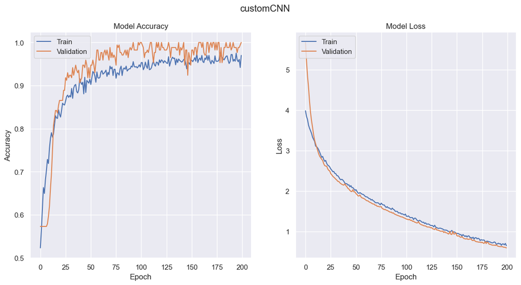

```python
import matplotlib.pyplot as plt

# Summarize history for accuracy
history= result
plt.figure(figsize=(12, 6))
plt.subplot(1, 2, 1)  # 1 row, 2 columns, first plot
plt.plot(history.history['accuracy'])
plt.plot(history.history['val_accuracy'])
plt.title('Model Accuracy')
plt.ylabel('Accuracy')
plt.xlabel('Epoch')
plt.legend(['Train', 'Validation'], loc='upper left')

# Summarize history for loss
plt.subplot(1, 2, 2)  # 1 row, 2 columns, second plot
plt.plot(history.history['loss'])
plt.plot(history.history['val_loss'])
plt.title('Model Loss')
plt.ylabel('Loss')
plt.xlabel('Epoch')
plt.legend(['Train', 'Validation'], loc='upper left')
plt.suptitle(f'{history.name}')
plt.show()
```

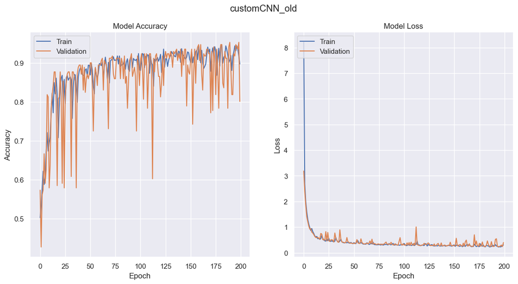

```python
# Summarize history for accuracy
history= result_old
plt.figure(figsize=(12, 6))
plt.subplot(1, 2, 1)  # 1 row, 2 columns, first plot
plt.plot(history.history['accuracy'])
plt.plot(history.history['val_accuracy'])
plt.title('Model Accuracy')
plt.ylabel('Accuracy')
plt.xlabel('Epoch')
plt.legend(['Train', 'Validation'], loc='upper left')

# Summarize history for loss
plt.subplot(1, 2, 2)  # 1 row, 2 columns, second plot
plt.plot(history.history['loss'])
plt.plot(history.history['val_loss'])
plt.title('Model Loss')
plt.ylabel('Loss')
plt.xlabel('Epoch')
plt.legend(['Train', 'Validation'], loc='upper left')
plt.suptitle(f'{history.name}')
plt.show()
```

```python
cnn_model.summary()
```

[output not shown]

```python
cnn_model_old.summary()
```

[output not shown]

```
Accuracy: 0.9894736842105263
Precision: 0.9912280701754386
Recall: 0.9826086956521739
F1 Score: 0.9868995633187774
```

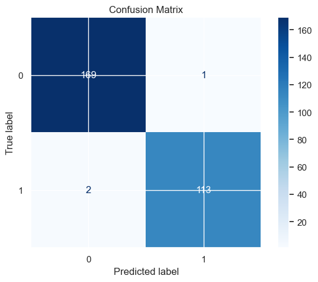

```python
from sklearn.metrics import accuracy_score, precision_score, recall_score, f1_score, confusion_matrix
import matplotlib.pyplot as plt
from sklearn.metrics import ConfusionMatrixDisplay
predictions = cnn_model.predict(test_X)
threshold = 0.5
predictions = (predictions > threshold).astype(int)
# Calculate metrics
accuracy = accuracy_score(test_Y, predictions)
precision = precision_score(test_Y, predictions)
recall = recall_score(test_Y, predictions)
f1 = f1_score(test_Y, predictions)

print(f"Accuracy: {accuracy}")
print(f"Precision: {precision}")
print(f"Recall: {recall}")
print(f"F1 Score: {f1}")

# Confusion Matrix
cm = confusion_matrix(test_Y, predictions)
disp = ConfusionMatrixDisplay(confusion_matrix=cm)
disp.plot(cmap=plt.cm.Blues)
plt.title('Confusion Matrix')
plt.show()
```

```python
print(classification_report(test_Y, predictions))
```

```
              precision    recall  f1-score   support

           0       0.99      0.99      0.99       170
           1       0.99      0.98      0.99       115

    accuracy                           0.99       285
   macro avg       0.99      0.99      0.99       285
weighted avg       0.99      0.99      0.99       285
```

```
Accuracy: 0.8456140350877193
Precision: 1.0
Recall: 0.6173913043478261
F1 Score: 0.7634408602150538
```

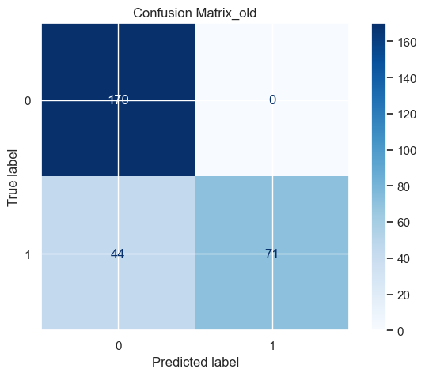

```python
from sklearn.metrics import accuracy_score, precision_score, recall_score, f1_score, confusion_matrix
import matplotlib.pyplot as plt
from sklearn.metrics import ConfusionMatrixDisplay
predictions = cnn_model_old.predict(test_X)
threshold = 0.5
predictions = (predictions > threshold).astype(int)
# Calculate metrics
accuracy = accuracy_score(test_Y, predictions)
precision = precision_score(test_Y, predictions)
recall = recall_score(test_Y, predictions)
f1 = f1_score(test_Y, predictions)

print(f"Accuracy: {accuracy}")
print(f"Precision: {precision}")
print(f"Recall: {recall}")
print(f"F1 Score: {f1}")

# Confusion Matrix
cm = confusion_matrix(test_Y, predictions)
disp = ConfusionMatrixDisplay(confusion_matrix=cm)
disp.plot(cmap=plt.cm.Blues)
plt.title('Confusion Matrix_old')
plt.show()
```

```python
print(classification_report(test_Y, predictions))
```

```
              precision    recall  f1-score   support

           0       0.79      1.00      0.89       170
           1       1.00      0.62      0.76       115

    accuracy                           0.85       285
   macro avg       0.90      0.81      0.82       285
weighted avg       0.88      0.85      0.84       285
```

```python
# Save the model to a file
filename = 'customCNN.pkl'
with open(filename, 'wb') as file:
    pickle.dump(cnn_model, file)

print(f"Model saved to {filename}")
```

```
Model saved to customCNN.pkl
```

Based on the provided graphs for the two models, let's assess their performance in terms of training and validation accuracy, as well as training and validation loss over epochs.

### Model labeled "customCNN_old"

**Accuracy:**

- The training and validation accuracy are both quite high, indicating the model has learned well.
- There is significant volatility in the validation accuracy, with several sharp peaks and valleys. This might suggest that the model is not stable in its predictions across different sets of validation data.

**Loss:**

- The training loss decreases smoothly, which is a good sign of learning.
- The validation loss, after the initial drop, shows spikes which could indicate overfitting or instability in how the model is generalizing to the validation data.

### Model labeled "customCNN"

**Accuracy:**

- The training accuracy climbs steadily and plateaus, which indicates stable learning.
- The validation accuracy also increases and then runs parallel with the training accuracy, staying consistently high. This suggests that the model is generalizing well without overfitting.

**Loss:**

- Both training and validation loss decrease steadily and converge closely, which is ideal. This shows that the model is learning and generalizing well without significant overfitting.